# Cyclistic Bike-Share Analysis

## Visualizations

Lets visualize the data to support our key findings and subsequently support our recommendations.

```r
# Cyclistic Targeted Visualizations

library(tidyverse)
library(ggplot2)
library(scales)

# Load the cleaned data
all_trips <- read_csv("cyclistic_cleaned_data.csv")
```

### Weekend vs Weekday Usage

Let’s distribute the weekend & weekday rides by rider type.

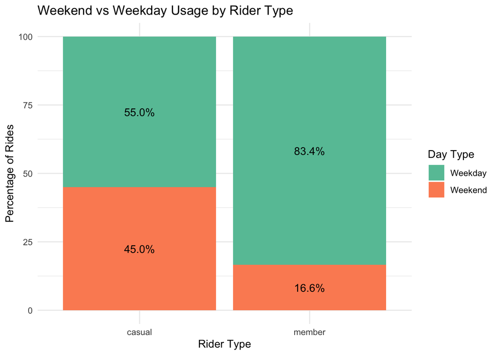

```r
# 1. Weekend vs Weekday Usage
all_trips <- all_trips %>%
  mutate(is_weekend = ifelse(day_of_week %in% c("Sat", "Sun"), "Weekend", "Weekday"))

weekend_usage <- all_trips %>%
  group_by(member_casual, is_weekend) %>%
  summarise(number_of_rides = n()) %>%
  mutate(percentage = number_of_rides / sum(number_of_rides) * 100)

ggplot(weekend_usage, aes(x = member_casual, y = percentage, fill = is_weekend)) +
  geom_bar(stat = "identity", position = "stack") +
  geom_text(aes(label = sprintf("%.1f%%", percentage)),
            position = position_stack(vjust = 0.5)) +
  labs(title = "Weekend vs Weekday Usage by Rider Type",
       x = "Rider Type", y = "Percentage of Rides",
       fill = "Day Type") +
  scale_fill_manual(values = c("Weekday" = "#66c2a5", "Weekend" = "#fc8d62")) +
  theme_minimal()
```

This usage chart shows the higher proportion of weekend rides for casual riders.

### Top stations

Let’s distribute the data by rider type across the top 3 stations.

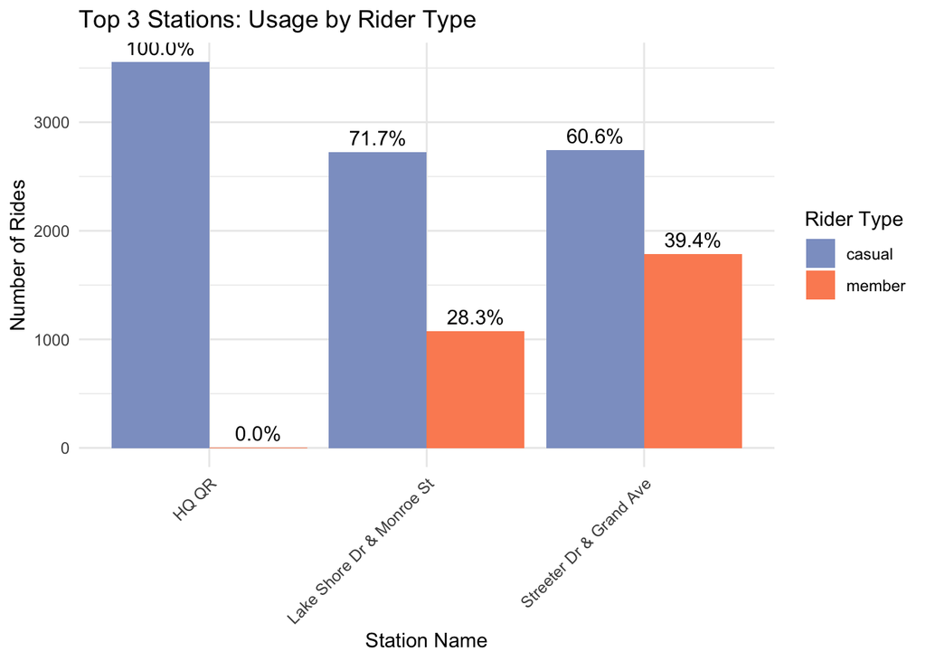

```r
# 2. Top Stations Analysis
top_stations <- all_trips %>%
  filter(start_station_name %in% c("HQ QR", "Streeter Dr & Grand Ave", "Lake Shore Dr & Monroe St")) %>%
  group_by(start_station_name, member_casual) %>%
  summarise(ride_count = n()) %>%
  mutate(percentage = ride_count / sum(ride_count) * 100)

ggplot(top_stations, aes(x = start_station_name, y = ride_count, fill = member_casual)) +
  geom_bar(stat = "identity", position = "dodge") +
  geom_text(aes(label = sprintf("%.1f%%", percentage)),
            position = position_dodge(width = 0.9), vjust = -0.5) +
  labs(title = "Top 3 Stations: Usage by Rider Type",
       x = "Station Name", y = "Number of Rides",
       fill = "Rider Type") +
  scale_fill_manual(values = c("casual" = "#8da0cb", "member" = "#fc8d62")) +
  theme_minimal() +
  theme(axis.text.x = element_text(angle = 45, hjust = 1))
```

### Ride duration comparision

Let’s see which type of riders take longer rides.

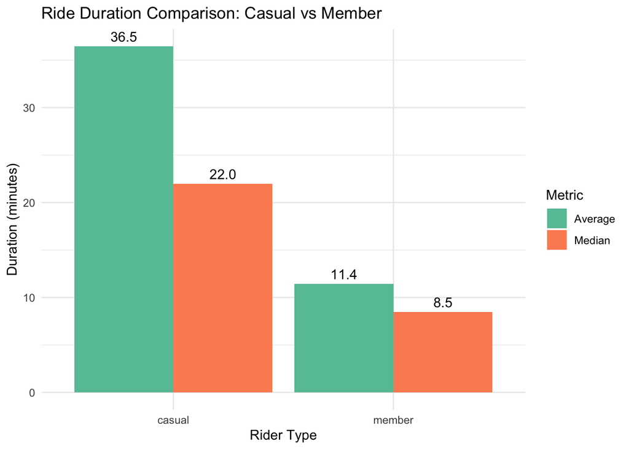

```r
# 3. Ride Duration Comparison
ride_duration <- all_trips %>%
  group_by(member_casual) %>%
  summarise(
    avg_duration = mean(ride_length),
    median_duration = median(ride_length)
  ) %>%
  pivot_longer(cols = c(avg_duration, median_duration),
               names_to = "metric", values_to = "duration")

ggplot(ride_duration, aes(x = member_casual, y = duration, fill = metric)) +
  geom_bar(stat = "identity", position = "dodge") +
  geom_text(aes(label = sprintf("%.1f", duration)),
            position = position_dodge(width = 0.9), vjust = -0.5) +
  labs(title = "Ride Duration Comparison: Casual vs Member",
       x = "Rider Type", y = "Duration (minutes)",
       fill = "Metric") +
  scale_fill_manual(values = c("avg_duration" = "#66c2a5", "median_duration" = "#fc8d62"),
                    labels = c("Average", "Median")) +
  theme_minimal()
```

The ride duration comparison illustrates that casual riders tend to take longer rides.

### Hourly usage pattern

Let’s see which time of the day is the busiest for which type of rider.

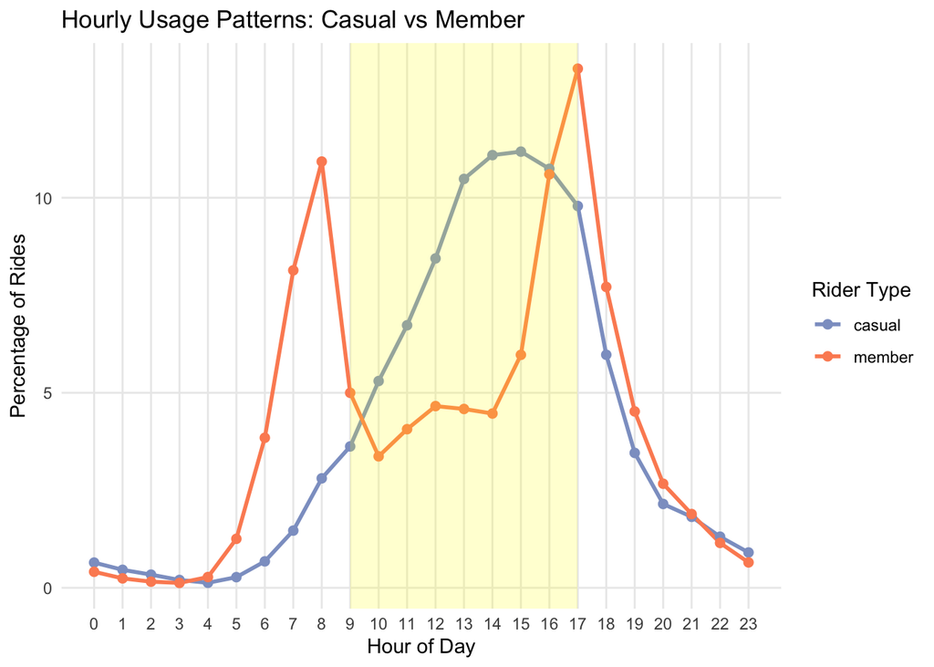

```r
# 4. Hourly Usage Patterns
hourly_usage <- all_trips %>%
  mutate(hour = hour(started_at)) %>%
  group_by(member_casual, hour) %>%
  summarise(number_of_rides = n()) %>%
  mutate(percentage = number_of_rides / sum(number_of_rides) * 100)

ggplot(hourly_usage, aes(x = hour, y = percentage, color = member_casual, group = member_casual)) +
  geom_line(size = 1) +
  geom_point(size = 2) +
  scale_x_continuous(breaks = seq(0, 23, 1)) +
  labs(title = "Hourly Usage Patterns: Casual vs Member",
       x = "Hour of Day", y = "Percentage of Rides",
       color = "Rider Type") +
  scale_color_manual(values = c("casual" = "#8da0cb", "member" = "#fc8d62")) +
  theme_minimal() +
  theme(panel.grid.minor = element_blank()) +
  annotate("rect", xmin = 9, xmax = 17, ymin = -Inf, ymax = Inf,
           alpha = 0.2, fill = "yellow")
```

This line graph shows the percentage of rides throughout the day for both casual riders and members. The yellow highlighted area represents the 9am-5pm period, clearly showing the difference in usage patterns during these hours, where casual riders are most active.